# Cerisier noir

### 3.1.2 Regression linéaire

```r
summary(lm. <- lm(volume ~ diametre, data = cerisiers))
```

```
Call:
lm(formula = volume ~ diametre, data = cerisiers)

Residuals:
      Min        1Q    Median        3Q       Max
-0.114193 -0.043986  0.002152  0.049480  0.135734

Coefficients:
            Estimate Std. Error t value Pr(>|t|)
(Intercept) -0.52306    0.04765  -10.98 7.62e-12 ***
diametre     2.82380    0.13789   20.48  < 2e-16 ***
---
Signif. codes:  0 ‘***’ 0.001 ‘**’ 0.01 ‘*’ 0.05 ‘.’ 0.1 ‘ ’ 1

Residual standard error: 0.0602 on 29 degrees of freedom
Multiple R-squared:  0.9353,    Adjusted R-squared:  0.9331
F-statistic: 419.4 on 1 and 29 DF,  p-value: < 2.2e-16
```

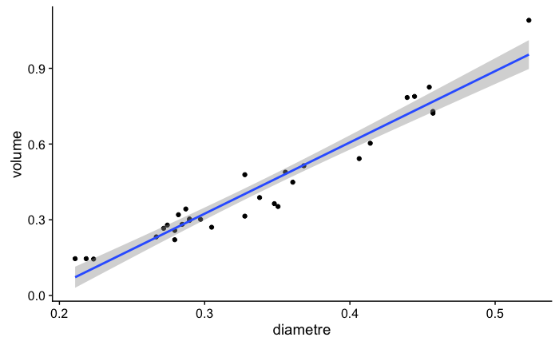

```r
lm. %>% (function(lm, model = lm[["model"]], vars = names(model))
  ggplot(model, aes_string(x = vars[2], y = vars[1])) +
  geom_point() + stat_smooth(method = "lm", formula = y ~ x))
```

L’ordonnée à l’origine est siginificative au seuil $\alpha$ de 0.05

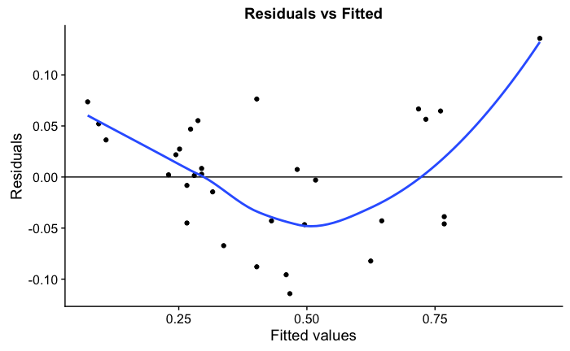

```r
#plot(lm., which = 1)
lm. %>% qplot(.fitted, .resid, data = .) +
  geom_hline(yintercept = 0) +
  geom_smooth(se = FALSE) +
  xlab("Fitted values") +
  ylab("Residuals") +
  ggtitle("Residuals vs Fitted")
```

Ce graphique est utilisé pour vérifier que la variance des erreurs de la variable dépendantes est constante. Cela permet de vérifier que la variance est indépendante de la valeur de la variable indépendante (condition d’homosceadasticité).

Les résidus semblent ne semblent pas être dispersés aléatoirement autours de zéro.

La variance des erreurs ne semble pas être constante sur ce graphique(hétéroscédasticité). Une transformation des données pourrait pallier au problème.

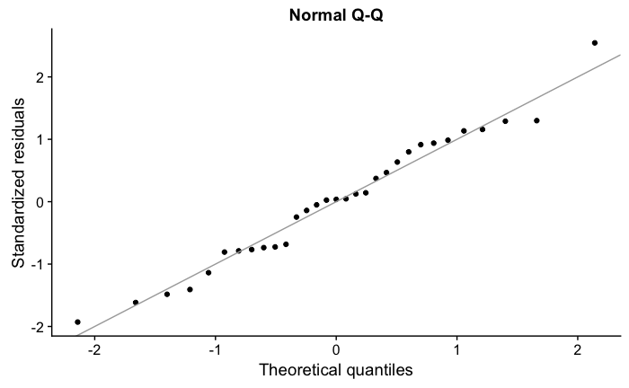

```r
lm. %>% qplot(sample = .stdresid, data = .) +
  geom_abline(intercept = 0, slope = 1, colour = "darkgray") +
  xlab("Theoretical quantiles") +
  ylab("Standardized residuals") +
  ggtitle("Normal Q-Q")
```

Ce graphique permet d’évaluer l’ajustement des résidus standardisés à la distribution normale.

l’ajustement des résidus standardisés à la distribution normale est pertinent.

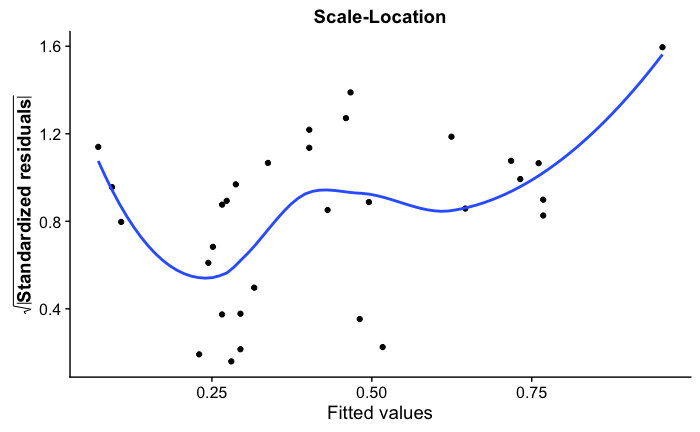

```r
lm. %>% qplot(.fitted, sqrt(abs(.stdresid)), data = .) +
  geom_smooth(se = FALSE) +
  xlab("Fitted values") +
  ylab(expression(bold(sqrt(abs("Standardized residuals"))))) +
  ggtitle("Scale-Location")
```

Ce graphique est utilisé pour vérifier que la variance des erreurs de la variable dépendantes est constante. Cela permet de vérifier que la variance est indépendante de la valeur de la variable indépendante (condition d’homosceadasticité).

Les racines carrées des résidus standardisés semblent ne semblent pas être dispersés au hasard autours de zéro.

La variance des erreurs ne semble pas être constante sur ce graphique(hétéroscédasticité). Une transformation des données pourrait pallier au problème.

#### 3.1.2.1 Transformation des données

```r
library(dplyr)
cerisiers %>% mutate ( log_volume= log(volume)) -> cerisiers
```

```r
library(dplyr)
cerisiers %>% mutate ( log_diametre= log(diametre)) -> cerisiers
```

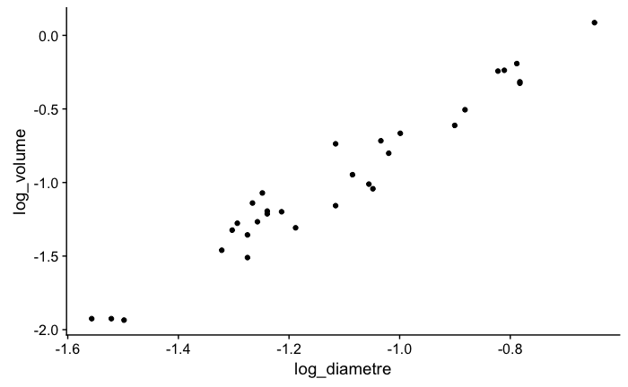

```r
library("dplyr")
library("cowplot")
ggplot(data=cerisiers)+
geom_point (mapping = aes (x=log_diametre, y =log_volume))
```

Le nuage de point semble compatible avec une régression linéaire

```r
library(dplyr)
cerisiers %>% mutate ( log_volume= log(volume)) -> cerisiers
```

```r
library(dplyr)
cerisiers %>% mutate ( log_diametre= log(diametre)) -> cerisiers
```

```r
summary(lm. <- lm(log_volume ~ log_diametre, data = cerisiers))
```

```
Call:
lm(formula = log_volume ~ log_diametre, data = cerisiers)

Residuals:
      Min        1Q    Median        3Q       Max
-0.205999 -0.068702  0.001011  0.072585  0.247963

Coefficients:
             Estimate Std. Error t value Pr(>|t|)
(Intercept)   1.46973    0.10233   14.36 1.02e-14 ***
log_diametre  2.19997    0.08983   24.49  < 2e-16 ***
---
Signif. codes:  0 ‘***’ 0.001 ‘**’ 0.01 ‘*’ 0.05 ‘.’ 0.1 ‘ ’ 1

Residual standard error: 0.115 on 29 degrees of freedom
Multiple R-squared:  0.9539,    Adjusted R-squared:  0.9523
F-statistic: 599.7 on 1 and 29 DF,  p-value: < 2.2e-16
```

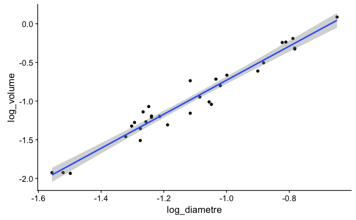

```r
lm. %>% (function(lm, model = lm[["model"]], vars = names(model))
  ggplot(model, aes_string(x = vars[2], y = vars[1])) +
  geom_point() + stat_smooth(method = "lm", formula = y ~ x))
```

L’ordonnée à l’origine est siginificative au seuil $\alpha$ de 0.05

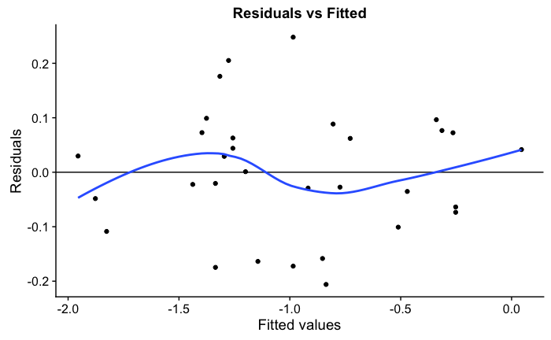

```r
#plot(lm., which = 1)
lm. %>% qplot(.fitted, .resid, data = .) +
  geom_hline(yintercept = 0) +
  geom_smooth(se = FALSE) +
  xlab("Fitted values") +
  ylab("Residuals") +
  ggtitle("Residuals vs Fitted")
```

Ce graphique est utilisé pour vérifier que la variance des erreurs de la variable dépendantes est constante. Cela permet de vérifier que la variance est indépendante de la valeur de la variable indépendante (condition d’homosceadasticité).

Les résidus standardisés semblent être réparties aléatoirement autours de 0. Ce graphique semble nous faire part d’une homoscedasticité.

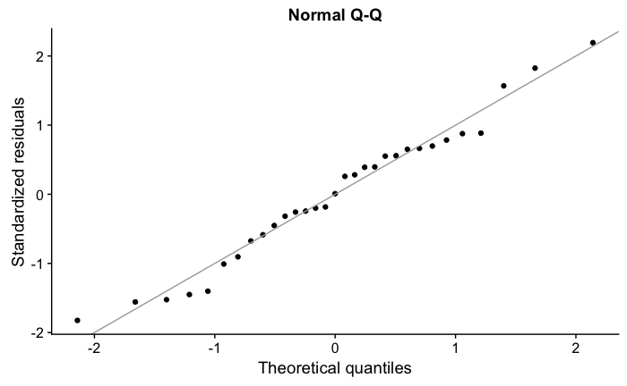

```r
lm. %>% qplot(sample = .stdresid, data = .) +
  geom_abline(intercept = 0, slope = 1, colour = "darkgray") +
  xlab("Theoretical quantiles") +
  ylab("Standardized residuals") +
  ggtitle("Normal Q-Q")
```

Ce graphique permet d’évaluer l’ajustement des résidus standardisés à la distribution normale.

l’ajustement des résidus standardisés à la distribution normale est pertinent.

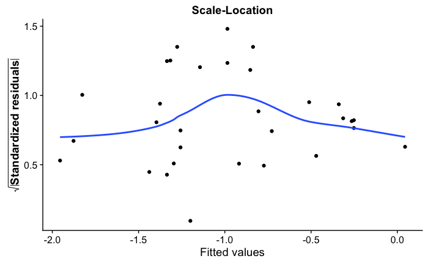

```r
lm. %>% qplot(.fitted, sqrt(abs(.stdresid)), data = .) +
  geom_smooth(se = FALSE) +
  xlab("Fitted values") +
  ylab(expression(bold(sqrt(abs("Standardized residuals"))))) +
  ggtitle("Scale-Location")
```

Ce graphique est utilisé pour vérifier que la variance des erreurs de la variable dépendantes est constante. Cela permet de vérifier que la variance est indépendante de la valeur de la variable indépendante (condition d’homosceadasticité).

Les racines carrées des résidus standardisés semblent être réparties aléatoirement autours de 0. Ce graphique semble nous faire part d’une homoscedasticité.

# 4 Discussion

Une relation linéaire cohérente est obtenue entre le logarithme du volume et le logarithme du diamètre. Toutes les conditions sont respectées : la distribution des résidus standardisés du logarithme du volume suit une distribution normale, les racinnes carrée des résidus standardisés sont à peu près répartis aléatoirement autours de 0 en fonction des valeurs ajustées. Les résidus sont également disposé aléatoirement en fonction des valeurs ajustées. Il y a homoscedasticité.

# 5 Conclusion

Il existe une relation linéaire entre le logarithme du volume de *P. cerotina* et son logarithme du diamètre. Il est possible de prédire la production de bois grâce au logarithme du diamètre.

# 6 Bibliographies

- The Minitab Student Handbook. Duxbury Press" de Ryan, T. A., Joiner, B. L. and Ryan, B. F. (1976)*.
- http://www.fcbn.fr/sites/fcbn.fr/files/ressource_telechargeable/fiche_prunus_serotina_sr.pdf